# FinalProject

How To Get A Exceptional Bottle of Wine On A Budget

Matthew Sebsibe

**Introduction**

While researching topics to focus on I went to Total Wine to buy my sister a gift. There I felt overwhelmed by the analysis paralysis that is a Walmart for wine. Displayed below in the chart below are some classifications of wines. Below you can see some classifications of wine. It is very expanisve. There are over 10,000 wine grape varieties in the world. Some major categories include: red, white, rose, sparkling and fortified wine. Personally, I wanted to create a project that I felt would be useful to myself in understanding this massive space. In addition, my goal is to use Data Science to simplify the area. Wine is synonymous to snobbery, however, there are many great bottles for relatively cheap. I will also explore if higher priced wine is worth it, but that will be explained more in subsequent sections.

Helpful resources: An image found in the book Wine Folly. I highly reccomend this for beginners intimdated but all the complexities of wine. This book is a good first step in understanding some terms Sommeliers use and differnt components that distinguish varieties of wine. As an added bonus, the book provides a lot of wine/food pairings. This book is good to get at libraries for its outstanding visuals.

[figure not shown]

Youtube Channels: https://www.youtube.com/user/askawinemaker/videos https://www.youtube.com/user/WineAlign

I learn best through visual and audio means so seeing someone explain features of bottles as well as basic wine ettiquette has helped me and I believe can be useful to others.

For the analysis of our data we will follow the The Data Science Pipeline in order to understand more about the data in front of us

**Disclaimer: This project is meant to explore the topic of wine in a healthy manner. Obviously safe and lawful consumption of alcohol is meant. Please be safe and know your limits.**

**Data Collection/Curation**

For my dataset, I was lucky to find one on Kaggle with over 100,000 entries. The link can be found here: https://www.kaggle.com/datasets/christopheiv/winemagdata130k . I was able to download this data in a CSV (Comma-separated values) file. What this means is a text-file that is seperated by commas to distinguish information. Within this dataset are many useful columns including the name of the bottle, country of origin, price, description, and points. Points refer to a score out of 100 that refer to the level of wine a sommelier would rate a wine. Wine Spectator a renowned wine magazine with 400000+ wine expert wine ratings has blind-taste tests of wine and scores wine using this scale:

95-100 Classic: a great wine

90-94 Outstanding: a wine of superior character and style

85-89 Very good: a wine with special qualities

80-84 Good: a solid, well-made wine

75-79 Mediocre: a drinkable wine that may have minor flaws

50-74 Not recommended

Different websites and magazines approach the scale differently, but the general trend is similar with preferences given to bottles over 90+ being excellent bottles. Without this dataset, the way I would approach scrapping is by doing a quick google search of wine data. Vivino is a great example of a website that stores many different reviewes of wine. However, it is very expansive and sorts by type of wine. So I would scrape a few thousand from each variety with a goal of about 10000+ reviews to have a good representation of bottom,mid, and high shelf wine from a multitude of wine varieties. Similar to Project 1, the data is tabulated fairly easily to scrape the HTML with BeautifulSoup. Luckly the dataset I found from Kaggle did a similar approach using data from WineMag. For the purposes of this project, the scale described above matches, but for Wine Magazine specific scale, that can be found in the link here: https://www.winemag.com/2010/04/09/you-asked-how-is-a-wines-score-determined/ . Wine Enthusiast Magazine also referred to as Wine Mag has some great resources for finding bottles of wine for every budget and is a great resource for beginners and experts alike to learn something new.

**Data Management / Representation**

For this project we will rely heavily on the Pandas library to represent our data. The matplot and seaborn library will be key in visualizing our data. Finally numpy will be key in preforming various operations on our data. As described above, the data is stored in a csv file. Once the file is imported into the Jupyter Notebook, all that is needed is to call the read_csv file to import all of the data stored. From there, it is the job of the data scientist to massage the data and make choices about missing data. For this data set, I can immediately drop the taster name, twitter handle, and unnamed column as none of these columns store useful data for our analysis.

```python
import pandas as pd
import matplotlib.pyplot as plt
import seaborn as sns
import numpy as np
from scipy import stats
```

```python
#wine set before dropping unnecessary operations
wine_data = pd.read_csv("winemag-data-130k-v2.csv")

#Taster name and twitter tag are unnecesary for analysis
wine_data.drop("taster_name", axis=1, inplace=True)
wine_data.drop("taster_twitter_handle", axis=1, inplace=True)
wine_data.drop("Unnamed: 0", axis=1, inplace=True)

wine_data.head()
```

|  | country | description | designation | points | price | province | region_1 | region_2 | title | variety | winery |
| --- | --- | --- | --- | --- | --- | --- | --- | --- | --- | --- | --- |
| 0 | Italy | Aromas include tropical fruit, broom, brimston... | Vulkà Bianco | 87 | NaN | Sicily & Sardinia | Etna | NaN | Nicosia 2013 Vulkà Bianco (Etna) | White Blend | Nicosia |
| 1 | Portugal | This is ripe and fruity, a wine that is smooth... | Avidagos | 87 | 15.0 | Douro | NaN | NaN | Quinta dos Avidagos 2011 Avidagos Red (Douro) | Portuguese Red | Quinta dos Avidagos |
| 2 | US | Tart and snappy, the flavors of lime flesh and... | NaN | 87 | 14.0 | Oregon | Willamette Valley | Willamette Valley | Rainstorm 2013 Pinot Gris (Willamette Valley) | Pinot Gris | Rainstorm |
| 3 | US | Pineapple rind, lemon pith and orange blossom ... | Reserve Late Harvest | 87 | 13.0 | Michigan | Lake Michigan Shore | NaN | St. Julian 2013 Reserve Late Harvest Riesling ... | Riesling | St. Julian |
| 4 | US | Much like the regular bottling from 2012, this... | Vintner's Reserve Wild Child Block | 87 | 65.0 | Oregon | Willamette Valley | Willamette Valley | Sweet Cheeks 2012 Vintner's Reserve Wild Child... | Pinot Noir | Sweet Cheeks |

For this model, I have chosen to drop rows without a wine bottle name, price, and point value. These will be needed in later sections and since we have so many data points we will still have many values to work with as shown below.

```python
#Dropping columns that do not have a price, point, or wine bottle name
before = len(wine_data.index)

wine_data = wine_data.dropna(subset=['price','points','title'])

after = len(wine_data.index)

tot = before - after
print("Number of values dropped = " + str(tot))

tot = tot/before
tot = tot*100
print("Percent of values dropped = " + str(tot) + "%")

print("Number of values left = " + str(after))
```

```
Number of values dropped = 8996
Percent of values dropped = 6.921544036746659%
Number of values left = 120975
```

**Since we still have over 120000 values to work with we can move forward with this model.**

Explanatory Data Analysis

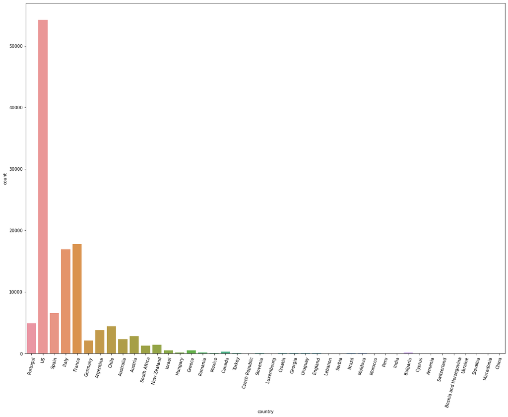

```python
plt.figure(figsize=(20,15))
ax = sns.countplot(x="country", data=wine_data)
ax.set_xticklabels(ax.get_xticklabels(),rotation = 75)
plt.show()
```

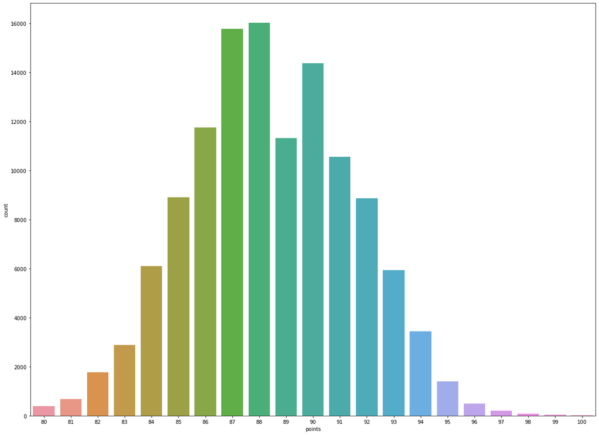

```python
plt.figure(figsize=(20,15))
ax = sns.countplot(x="points", data=wine_data)
ax.set_xticklabels(ax.get_xticklabels(),rotation = 0)
plt.show()
```

**Fine tune plot**

```python
#plt.plot(wine_data['price'])
```

**Hypothesis Testing**

```python
wine_data.corr()
```

[output not shown]

```python
less_than_100 = wine_data[wine_data["price"] <= 100]
less_than_100.corr()
```

[output not shown]

```python
less_than_50 = wine_data[wine_data["price"] <= 50]
less_than_50.corr()
```

[output not shown]

```python
sns.lmplot(x ="price", y ="points", data = wine_data, order = 2, ci = None)
```

[output not shown]

**Communication of insights attained**

```python
less_than_15_dollars = wine_data[wine_data["price"] <= 20]
cheap_excellent = less_than_15_dollars[less_than_15_dollars["points"] >= 95]
cheap_excellent.head(100)
```

[output not shown]

```python
one_hundred_points = wine_data[wine_data["points"] == 99]
one_hundred_points.head()
```

[output not shown]

Visit local winery. For Maryland the link is provided below.

[Interactive Wine Map of Maryland](https://marylandwine.com/map/)